# Contents

1. Regular networks
2. Random networks

```python
import networkx as nx
import numpy as np
import matplotlib as mpl
import matplotlib.pyplot as plt
%matplotlib inline

nx.__version__, mpl.__version__
```

```
('3.1', '3.5.2')
```

We are often interested in three properties of a network:

1. its degree distribution $P_k$ (and its moments $\langle{k}\rangle$ and $\langle{k^2}\rangle$),
2. its average clustering coefficient $C$, and
3. its average shortest path length $L$.

A real network tends to have a **scale-free** $P_k$, a high $C$, and a short $L$ (i.e. the **small-world** property). In the coming three tutorials, we will learn various network models that try to capture these properties.

Let $N$ be the size of the following networks.

```python
def kCL(G):
    k = np.mean([k for n, k in G.degree])
    C = nx.average_clustering(G)
    L = nx.average_shortest_path_length(G)
    return '<k> = %.3g, C = %.3g, and L = %.3g.' % (k, C, L)
```

# 1. Regular networks

A $K$-regular network has the same degree $K$ for all nodes, so $P_k=\delta{\left(k-K\right)}$. In addition to $K$, its properties also depend on its **dimension**.

## 1.1 Rings

A ring is $2$-regular and $1$-dimensional. (It is just a line with the two ends conencted.) You can construct it with `cycle_graph`.

If we additionally connect each node to its $\left(K−2\right)$ nearest neighbours, the resultant network is $K$-regular. While it does not have a proper name, we may call it a $K$-regular ring.

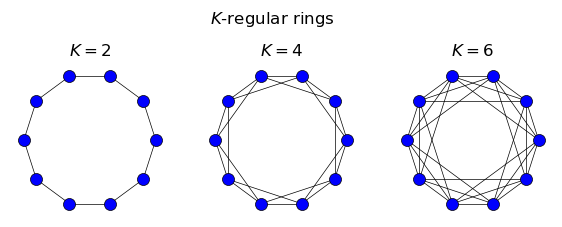

```python
def K_ring(N, K):
    # assuming K is even for simplicity
    if K<=2: return nx.cycle_graph(N)
    ring = nx.empty_graph(N)
    for n in range(N):
        ring.add_edges_from([(n, (n+i+1)%N) for i in range(K//2)])
        ring.add_edges_from([(n, (n-i-1)%N) for i in range(K//2)])
    return ring

fig, ax = plt.subplots(1, 3, figsize=(7, 2))
fig.suptitle('$K$-regular rings', y=1.15)
for K, col in zip([2, 4, 6], ax):
    ring = K_ring(10, K)
    col.set_title('$K=%d$' % K)
    nx.draw_circular(ring, ax=col, node_size=75, node_color='b',
                     width=.5, linewidths=.5, edgecolors='k')
```

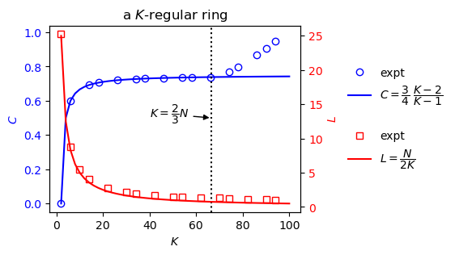

```python
N = 100
ring = lambda K: K_ring(N, K)
Ks = range(2, N, 4)
Cs = [nx.average_clustering(ring(K)) for K in Ks]
Ls = [nx.floyd_warshall_numpy(ring(K)).sum()/(N*(N-1)) for K in Ks]
KsCont = np.linspace(2, N)

plt.figure(figsize=(4, 3))
plt.plot(Ks, Cs, 'bo', mfc='none', markevery=.05, label='expt')
plt.plot(KsCont, 3*(KsCont-2)/(4*(KsCont-1)), 'b-',
         label='$C=\dfrac{3}{4}\;\dfrac{K-2}{K-1}$')
plt.legend(loc='center left', bbox_to_anchor=(1.15,.67), frameon=False)
plt.xlabel('$K$'); plt.ylabel('$C$', color='b')
plt.tick_params(axis='y', labelcolor='b')

plt.axvline(2*N/3, c='k', ls=':')
plt.annotate('$K=\dfrac{2}{3}N$', (2*N/3, .5), (40, .5),
             arrowprops={'arrowstyle': '-|>', 'color': 'k'})

plt.gca().twinx().plot(Ks, Ls, 'rs', mfc='none', markevery=.05, label='expt')
plt.plot(KsCont, N/2/KsCont, 'r', label=r'$L=\dfrac{N}{2K}$')
plt.legend(loc='center left', bbox_to_anchor=(1.15,.33), frameon=False)
plt.ylabel('$L$', color='r')
plt.tick_params(axis='y', labelcolor='r')

plt.title('a $K$-regular ring')
plt.show()
```

### Complete network.

A complete network is **fully connected**, so it is $\left(N-1\right)$-regular. In some sense, we may regard it as an $\left(N-1\right)$-regular ring. It is the densest among all networks of the same size. It has $C=1$ and $L=1$ because all nodes are each other's neighbours.

You can create it with `complete_graph`.

```
A 10-node complete graph has <k> = 9, C = 1, and L = 1.
```

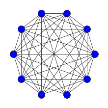

```python
complete = nx.complete_graph(10)
print('A %d-node complete graph has ' % len(complete) + kCL(complete))

plt.figure(figsize=(2, 2))
nx.draw_circular(complete, node_size=100, node_color='b',
                 width=.5, linewidths=.5, edgecolors='k')
```

A complete network is $\left(N-1\right)$-dimensional according to mathematicians' arguments. Since a ring resembles a complete network once $K$ approaches $N$, we can deduce that a ring's dimension grows from $1$ to $\left(N-1\right)$ as $K$ increases. We may also define $K=\dfrac{2}{3}N$ as the critical point between a ring and a complete network because of the change in $C$.

## 1.2 Regular lattices

Without delving into its confusing and abstract definition in mathematics, a lattice is basically just a **grid**. A regular lattice is a grid on which all nodes have the same degree. (Here are examples of [*irregular* lattices](https://www.google.com/search?q=irregular+lattice).)

### Two-dimensional lattices.

The most common form of a $2$-dimensional regular lattice is a square lattice. You can create it with `grid_2d_graph`. It has $C=0$ (obviously) and $L\sim N^{1/2}$.

Despite the same $K=4$, a square lattice and a $4$-regular ring possess quite different $C$ and $L$ because of the difference in their dimensions: the former is strictly $2$-dimensional, while the latter's dimension is somewhat larger than $1$ (and arguably almost $1$ for a large $N$). From this simple comparison you can see the significance of a network's dimension.

```
A 4x4 periodic square lattice has 16 nodes, <k> = 4, C = 0, and L = 2.13.
```

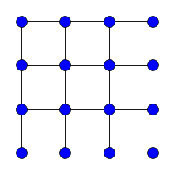

```python
row, col = 4, 4 # numbers of nodes per side
square = nx.grid_2d_graph(row, col, periodic=True)
print('A %dx%d periodic square lattice has ' % (row, col) +
      '%d nodes, ' % len(square) + kCL(square))

plt.figure(figsize=(2, 2))
nx.draw(square, {n: n for n in square},
        node_size=100, node_color='b',
        width=.5, linewidths=.5, edgecolors='k')
```

Other examples of a $2$-dimensional regular lattice include a triangular lattice ($6$-regular) and a hexagonal lattice ($3$-regular). You can create them with `triangular_lattice_graph`, and `hexagonal_lattice_graph` respectively. Note that their parameters follow a different logic from those of `grid_2d_graph`.

```
A 4x6 periodic triangular lattice has 12 nodes, <k> = 6, C = 0.467, and L = 1.45.
```

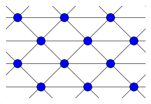

```python
row, col = 4, 6 # number of triangles per row or column
triangle = nx.triangular_lattice_graph(row, col, periodic=True)
print('A %dx%d periodic triangular lattice has ' % (row, col) +
      '%d nodes, ' % len(triangle) + kCL(triangle))

# it is ugly to plot such a periodic lattice directly
# so I will plot its cells using its non-periodic counterpart

triVisual = nx.triangular_lattice_graph(row+1, col+2, periodic=False)
plt.figure(figsize=(3, 2))
plt.xlim(.75, (col+1.5)/2)
plt.ylim(3**.5/4, 3**.5/2*(row+.5))
nx.draw(triVisual, {n: p for n,p in triVisual.nodes('pos')},
        node_size=100, node_color='b',
        width=.5, linewidths=.5, edgecolors='k')
```

```
A 2x4 periodic hexagonal lattice has 16 nodes, <k> = 3, C = 0, and L = 2.4.
```

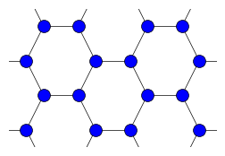

```python
row, col = 2, 4 # number of hexagons per row or column
hexagon = nx.hexagonal_lattice_graph(row, col, periodic=True)
print('A %dx%d periodic hexagonal lattice has ' % (row, col) +
      '%d nodes, ' % len(hexagon) + kCL(hexagon))

hexVisual = nx.hexagonal_lattice_graph(row+1, col+1, periodic=False)
plt.figure(figsize=(3, 2))
plt.xlim(1, 7)
plt.ylim(3**.5/2*1.5, 3**.5/2*5.5)
nx.draw(hexVisual, {n: p for n,p in hexVisual.nodes('pos')},
        node_size=100, node_color='b',
        width=.5, linewidths=.5, edgecolors='k')
```

### Hypercubic lattices.

A hypercubic lattice is a lattice whose unit cell is a hypercube, so a ring, a square lattice, and a cubic lattice are respectively $1$-, $2$-, and $3$-dimensional hypercubic lattices. More generally, the unit cell of a hypercubic lattice is allowed to be a **hyperrectangle**, which has different lengths on each side. You can create such a hyperrectangular lattice with `grid_graph`.

A $d$-dimensional periodic hypercubic lattice possesses $L\sim N^{1/d}$. In fact, a high-dimensional network usually yields a short $L$.

```
For $d$=2, the slope of the fit is 0.502.
For $d$=3, the slope of the fit is 0.346.
For $d$=4, the slope of the fit is 0.280.
```

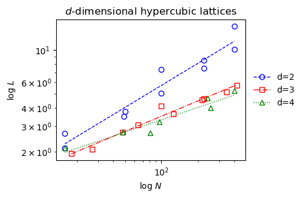

```python
samples_fixDim = { # arbitrary samples
    2: [[2,8], [5,10], [4,25], [9,25], [8,50]] +
       [[side]*2 for side in [4, 7, 10, 15, 20]],
    3: [[2,3,3], [3,4,4], [3,3,11], [5,5,9], [6,7,10]] +
       [[side]*3 for side in [3, 4, 5, 6, 7]],
    4: [[2,2,3,4], [2,3,4,4], [2,3,4,10], [2,4,5,10]] +
       [[side]*4 for side in [2, 3, 4]]}
Ls_fixDim, Ns_fixDim = {}, {}

plt.figure(figsize=(4, 3))
for d in samples_fixDim:
    Ls_fixDim[d], Ns_fixDim[d] = [], []
    for config in samples_fixDim[d]:
        hypercube = nx.grid_graph(config, periodic=True)
        N = hypercube.number_of_nodes()
        Ls_fixDim[d] += [nx.floyd_warshall_numpy(hypercube).sum()/(N*(N-1))]
        Ns_fixDim[d] += [N]

    fmt = ['ob--', 'sr-.', '^g:'][d-2]
    Ns, Ls = Ns_fixDim[d], Ls_fixDim[d]
    plt.loglog(Ns, Ls, fmt[:2], mfc='none')
    m, c = np.polyfit(np.log(Ns), np.log(Ls), 1)
    Ns = np.array(sorted(list(set(Ns))))
    plt.plot(Ns, np.exp(c)*Ns**m, fmt[1:], lw=1)
    plt.plot([], [], fmt, mfc='none', lw=1, label='d=%d'%d)
    print('For $d$=%d, the slope of the fit is %.3f.' % (d, m))

plt.legend(loc='center left', bbox_to_anchor=(1,.5), frameon=False)
plt.xlabel('$\log{\,N}$')
plt.ylabel('$\log{\,L}$')
plt.title('$d$-dimensional hypercubic lattices')
plt.show()
```

### The meaning of "lattice".

So what is a "lattice" actually? In case you wonder, mathematicians define it in an abstract way that laymen can hardly understand. (Reading Wikipedia may not be so helpful this time.)

Informally speaking, the nodes on a lattice are so regularly arranged that the lattice looks **self-repeating**, and the edges on it only conenct nodes that are "close" enough with respect to some kind of "distance". (A ring is therefore sometimes referred to as a "ring lattice".) Here I am illustrating the second idea with the Euclidean distance between two nodes, but the resultant networks are not lattices because of the irregular arrangement of their nodes.

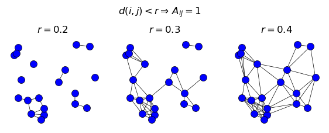

```python
N = 20
np.random.seed(5056)
demo = nx.Graph(pos=np.random.random((N, 2)))
demo.add_nodes_from([(i, {'c': demo.graph['pos'][i]}) for i in range(N)])
d = lambda i, j: np.sum( (demo.graph['pos'][i]-demo.graph['pos'][j])**2 )**.5

fig, ax = plt.subplots(1, 3, figsize=(7, 2))
fig.suptitle(r'$d\left({i,j}\right)<r\Rightarrow\,A_{ij}=1$', y=1.15)
for r, col in zip([.2, .3, .4], ax):
    demo.add_edges_from(
        [(i, j) for i in range(N) for j in range(i) if d(i, j)<r])
    col.set_title('$r=%.3g$' % r)
    nx.draw(demo, pos=demo.graph['pos'], ax=col,
            node_size=75, node_color='b',
            width=.5, linewidths=.5, edgecolors='k')
```

# 2. Random networks

A random network may be defined in terms of its number of edges or connection probability, which Erdős and Rényi (1958) and Gilbert (1959) proposed respectively.

- In the Erdős-Rényi (ER) model, a random network contains $N$ nodes, and $E$ out of the $E_0=\left(\matrix{N\\2}\right)$ possible edges are drawn to be realized.
- In the Gilbert model, a random network contains $N$ nodes, and each possible edge is realized with probability $p$. This is also called the binomial model.

The two models are statistically similar but distinct. While an ER network definitely has $E$ edges, the number of edges on a Gilbert network fluctuates around $\langle{E}\rangle=pE_0$. The probability that a Gilbert network has exactly $E$ edges reads

\begin{align} P_E = \left(\matrix{E_0\\E}\right) p^E \left(1-p\right)^{E_0-E}\,. \end{align}

## 2.1 The Erdős-Rényi model

Nowadays, we somehow only pay tribute to Erdős and Rényi while sticking to Gilbert's formulation. In NetworkX, `erdos_renyi_graph` refers to the Gilbert model, so does `gnp_random_graph`. You can call the original ER model with `gnm_random_graph`.

In addition, the time complexity of another function `fast_gnp_random_graph` is $O{\left(N+E\right)}$, whereas `erdos_renyi_graph` costs $O{\left(N^2\right)}$. If the desired network is sparse, i.e. $E\ll E_0$, the former function is much faster than the latter.

```python
er_func = nx.erdos_renyi_graph     # O(N^2)
er_fast = nx.fast_gnp_random_graph # O(N+E)
```

### Degree distribution.

The ER network's degree distribution follows a **binomial distribution**

\begin{align} P_k = \left(\matrix{N-1\\k}\right) p^k \left(1-p\right)^{N-1-k}\,. \end{align}

If $k \ll N$, the first term approaches $\dfrac{\left(N-1\right)^k}{k!}$ and the third term reduces to $e^{-\langle{k}\rangle}$ because

\begin{align} \ln{\big[\left(1-p\right)^{N-1-k}\big]} &= \left(N-1-k\right)\ln{\left(1-\dfrac{\langle{k}\rangle}{N-1}\right)} \\ &\approx -\left(N-1-k\right)\dfrac{\langle{k}\rangle}{N-1} & \left(N\gg\langle{k}\rangle\right) \\ &= -\langle{k}\rangle\left(1-\dfrac{k}{N-1}\right) \\ &\approx -\langle{k}\rangle\,. \end{align}

Hence, if $N\gg\langle{k}\rangle$, the binomial distribution becomes a **Poisson distribution**

\begin{align} P_k \stackrel{N\gg\langle{k}\rangle}{=} \dfrac{\left(N-1\right)^k}{k!} p^k e^{-\langle{k}\rangle} = \dfrac{\langle{k}\rangle^k}{k!} e^{-\langle{k}\rangle} \,, \end{align}

where $\langle{k}\rangle=p\left(N-1\right)\approx pN$.

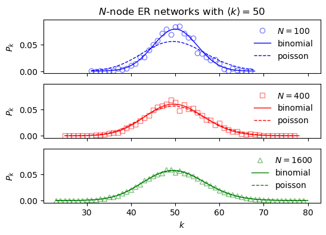

```python
from scipy.special import comb, factorial as F
trials, kAvg = 10, 50
fig, ax = plt.subplots(
    3, 1, sharex=True, sharey=True, figsize=(6, 4))

for i, (a, N) in enumerate(zip(ax, [100, 400, 1600])):
    fmt = ['bo', 'rs', 'g^'][i]
    degs = [k for t in range(trials) for n, k in
            er_fast(N, kAvg/(N-1), seed=5056+t).degree]
    kMin, kMax = min(degs), max(degs)
    a.plot(range(kMin, kMax+1), (np.bincount(degs)/(N*trials))[kMin:kMax+1],
           fmt, mfc='none', alpha=.5, label='$N=%d$'%N)

    ks, p = np.linspace(kMin, kMax+1), kAvg/(N-1)
    a.plot(ks, comb(N-1,ks)*p**ks*(1-p)**(N-1-ks),
           fmt[0], lw=1, label='binomial')
    a.plot(ks, kAvg**ks/F(ks)*np.exp(-kAvg),
           fmt[0]+'--', lw=1, label='poisson')
    a.set_ylabel('$P_k$')
    a.legend(loc=1, frameon=False)

ax[2].set_xlabel('$k$')
ax[0].set_ylim(a.get_ylim()[0], a.get_ylim()[1]*1.1)
ax[0].set_title(r'$N$-node ER networks with $\langle{k}\rangle=%d$'%kAvg)
plt.show()
```

Consider the binomial form of $P_k$. Its second moment reads

\begin{align} \langle{k^2}\rangle &= p\left(1-p\right)\left(N-1\right) + p^2\left(N-1\right)^2 \\ &\approx p\left(1-p\right) N + \left(pN\right)^2\,, \end{align}

so the variance in degree is

\begin{align} \sigma_k^2 &= \langle{k^2}\rangle-\langle{k}\rangle^2 \\ &= p\left(1-p\right)\left(N-1\right) \\ &\approx p\left(1-p\right)N\,. \end{align}

As $N$ grows, $P_k$ approaches a Poisson distribution, which turns out to have $\langle{k^2}\rangle = \langle{k}\rangle^2+\langle{k}\rangle$.

\begin{align} \langle{k^2}\rangle &= \sum_{k\geq0} {k^2 \dfrac{\langle{k}\rangle^k}{k!} e^{-\langle{k}\rangle}} \\ &= \langle{k}\rangle e^{-\langle{k}\rangle} \sum_{k\geq1} {k \dfrac{\langle{k}\rangle^{k-1}}{\left(k-1\right)!}} \\ &= \langle{k}\rangle e^{-\langle{k}\rangle} \Bigg[\sum_{k\geq1} {\left(k-1\right) \dfrac{\langle{k}\rangle^{k-1}}{\left(k-1\right)!}} +\sum_{k\geq1} {\dfrac{\langle{k}\rangle^{k-1}}{\left(k-1\right)!}}\Bigg] \\ &= \langle{k}\rangle e^{-\langle{k}\rangle} \Bigg[\langle{k}\rangle \sum_{k\geq2} {\dfrac{\langle{k}\rangle^{k-2}}{\left(k-2\right)!}} +\sum_{k\geq1} {\dfrac{\langle{k}\rangle^{k-1}}{\left(k-1\right)!}}\Bigg] \\ &= \langle{k}\rangle e^{-\langle{k}\rangle} \left(\langle{k}\rangle e^{\langle{k}\rangle}+e^{\langle{k}\rangle}\right) & \left(e^x=\sum_{n=0}^\infty{\frac{x^n}{n!}}\right)\\ &= \langle{k}\rangle^2+\langle{k}\rangle \end{align}

Hence the variance in degree simply reduces to $\sigma_k^2 = \langle{k}\rangle$.

```python
trials, kAvg = 10, 50
print('%5s%10s%10s' % ('N', 'V', 'theory'))
print('='*25)
for N in [100, 400, 1600]:
    p = kAvg/(N-1)
    vBar = np.mean([ np.var([k for n, k in er_fast(N, p, 5056+t).degree])
                     for t in range(trials) ])
    print('%5d%10.3g%10.3g' % (N, vBar, p*(1-p)*(N-1)))
```

```
    N         V    theory
=========================
  100      24.6      24.7
  400      42.6      43.7
 1600      49.3      48.4
```

After all, both binomial distribution and Poisson distriubtion are bell-shaped, so an ER network lacks nodes with extreme degrees. If our social network were random, there would not be any celebrities at all.

### Clustering coefficient.

A node's clustering coefficient is the probability of its neighbours' connection. On an ER network, the probability is homogeneously $p$ because all edges are random, so all nodes are expected to have a clustering coeffcient $c=p$. This means that $C\equiv\langle{c}\rangle=p=\dfrac{\langle{k}\rangle}{N-1}$.

If $\langle{k}\rangle$ is fixed, $C$ drops with the network's size as $C\sim N^{-1}$. This prediction does not match empirical observations, though.

```python
trials, kAvg = 10, 50
print('%5s%10s%10s' % ('N', 'C', 'theory'))
print('='*25)
for N in [100, 400, 1600]:
    p = kAvg/(N-1)
    cBar = np.mean([ nx.average_clustering(er_fast(N, p, 5056+t))
                     for t in range(trials) ])
    print('%5d%10.3g%10.3g' % (N, cBar, p))
```

```
    N         C    theory
=========================
  100     0.505     0.505
  400     0.125     0.125
 1600    0.0313    0.0313
```

### Shortest path length.

Suppose that our world is a random network with $7\times10^9$ nodes. If we all have $50$ friends, then the average interpersonal distance is around $6$ despite our world's enormous size. This is the origin of "six degrees of separation", a famous term in popular science.

In general, a network is said to possess the "**small-world property**" if it shows $L\sim{\ln{N}}$.

```python
trials, kAvg = 10, 50
print('%5s%10s%10s' % ('N', 'L', 'theory'))
print('='*25)
for N in [100, 225, 400]:
    p = kAvg/(N-1)
    lBar = np.mean([ nx.floyd_warshall_numpy(er_fast(N, p, 5056+t)).sum()/(N*(N-1))
                     for t in range(trials) ])
    print('%5d%10.3g%10.3g' % (N, lBar, np.log(N)/np.log(kAvg)))
```

```
    N         L    theory
=========================
  100       1.5      1.18
  225      1.78      1.38
  400      1.88      1.53
```

## 2.2 Percolation

When we are given a configuration $\left(N,p\right)$, we naturally ask how connected the resultant ER network is. This question turns out to be closely related to [percolation theory](https://en.wikipedia.org/wiki/Percolation_theory), which studies the spread of a substance through a medium.

For example, a sponge with $N$ holes may be modelled as a network. If a hole absorbs water and passes its to an adjacent hole, thus soaking the substance in between, with probability $p$, how wet do we expect the sponge to become eventually?

### Giant component.

A giant component $g$ is a component whose size is comparable to the entire network. Practically, we may regard a network's uniquely largest component as the giant component if its size breaks above a certain threshold.

If a giant component exists, a node either belongs to or does not belong to the component. Let $N_g$ be the number of nodes inside the giant component, then its fractional size is $S\equiv\dfrac{N_g}{N}$, whereas the fraction of nodes outside it is $u\equiv1-S$. Given that node $i$ is outside the giant component, either statement below is true for it and another node $j$.

1. $i$ is not connected with $j$. This happens with probability $1-p$.
2. $i$ is connected with $j$, but $j$ is also outside the component. This happens with probability $pu$.

Because there are $N-1$ choices for $j$, the probability that $i$ is outside the giant component reads $\left(1-p+pu\right)^{N-1}$. Meanwhile, the fraction of nodes outside the component is just the probability for a node to be outside it, so $u=\left(1-p+pu\right)^{N-1}$.

\begin{align} \therefore \ln{u} &= \left(N-1\right) \ln{\big[1-p\left(1-u\right)\big]} \\ &= \left(N-1\right) \ln{\bigg[1-\dfrac{\langle{k}\rangle}{N-1}\left(1-u\right)\bigg]} \\ &\approx -\left(N-1\right) \dfrac{\langle{k}\rangle}{N-1}\left(1-u\right) & \left(N\gg\langle{k}\rangle\right) \\ &= -\langle{k}\rangle\left(1-u\right) \\ \end{align}

This implies $u=e^{-\langle{k}\rangle\left(1-u\right)}$ and thus

\begin{align} S= 1-e^{-\langle{k}\rangle S}\,. \end{align}

The giant component's size depends on $\langle{k}\rangle$. The equation only has a trivial solution $S=0$ for $\langle{k}\rangle\in\left[0, 1\right)$, but a non-trivial solution emerges once $\langle{k}\rangle>1$. Therefore,

\begin{align} \langle{k}\rangle=1 \end{align}

marks the **phase transition** from the absence to the presence of a giant component.

In terms of sponge and water, we expect to see a mostly wet sponge once $p$ exceeds $N^{-1}$.

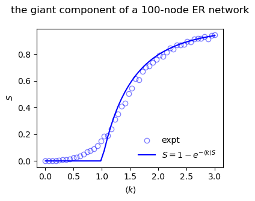

```python
N, trials = 100, 100
ks = np.linspace(0, 3)
Ngs = np.zeros((trials, len(ks)), int)
threshold = 0 # the minimum fractional size for a component
              # to be regarded as the giant component

for i, k in enumerate(ks):
    for t in range(trials):
        ER = er_fast(N, k/(N-1), 5056+t*trials+i)
        for c in nx.connected_components(ER):
            if len(c) > threshold*N:
                if len(c) > Ngs[t, i]:
                    Ngs[t, i] = len(c)
                elif len(c) == Ngs[t, i]: # regard the largest component
                    Ngs[t, i] = 0         # as a giant component
                    break                 # only if its size is unique
Ss_expt = Ngs.mean(0)/N

def solve_S_with(k):
    Ss = np.linspace(0, 1)
    argmin = np.argmin(np.abs(1-np.exp(-k*Ss)-Ss)[1:])+1
    upper = Ss[argmin+1] if argmin != len(Ss)-1 else 1
    Ss = np.linspace(Ss[argmin-1], upper, 100)
    return Ss[np.argmin(np.abs(1-np.exp(-k*Ss)-Ss))]
Ss_theory = np.array([solve_S_with(k) for k in ks])

plt.figure(figsize=(4, 3))
plt.plot(ks, Ss_expt, 'bo', mfc='none', alpha=.5, label='expt')
plt.plot(ks, Ss_theory, 'b-', label=r'$S=1-e^{-\langle{k}\rangle S}$')
plt.title('the giant component of a %d-node ER network\n' % N)
plt.legend(loc=4, frameon=False)
plt.xlabel(r'$\langle{k}\rangle$')
plt.ylabel('$S$')
plt.show()
```

### Connectedness.

We know that $\langle{k}\rangle>1$ implies the existence of a giant component. A follow-up question asks how large $\langle{k}\rangle$ should at least be so that the ER network is connected, i.e. its giant component is the only component and thus the entire network.

If there are $N_g$ nodes in the giant component, the probability that a node falls outside it is $\left(1-p\right)^{N_g}$, which becomes $\left(1-p\right)^N$ as we focus on the transition to the connected regime $N_g\to N$. Since $\lim\limits_{n \rightarrow \infty} {\left(1+\dfrac{x}{n}\right)^n} = e^x$, the probability can be simplified to

\begin{align} \left(1-p\right)^N = \left(1-\dfrac{\langle{k}\rangle}{N}\right)^N \stackrel{N\rightarrow\infty}{=} e^{-\langle{k}\rangle} \end{align}

when $N$ is large. Therefore, the probability that an ER network is connected, i.e. all nodes are inside the giant component, reads $\left( 1-e^{-\langle{k}\rangle} \right)^N$. It is the expected frequency to observe a connected ER network.

Meanwhile, $Ne^{-\langle{k}\rangle}$ nodes are expected to fall outside the giant component. By requiring less than one node falls outside it, we get

\begin{align} Ne^{-\langle{k}\rangle} < 1\quad \Rightarrow\quad\langle{k}\rangle > \ln{N} \quad \Rightarrow\quad p > \dfrac{\ln{N}}{N} \,. \end{align}

In terms of sponge and water, we expect to see a completely wet sponge if $p > \dfrac{\ln{N}}{N}$.

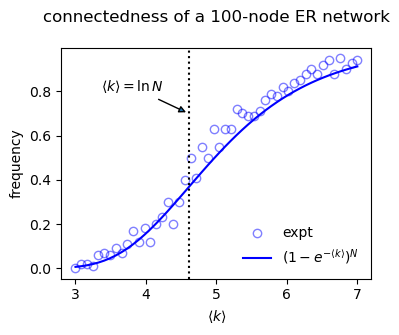

```python
N, trials = 100, 100
ks = np.linspace(3, 7)
Fs = np.array([ [nx.is_connected(er_fast(N, k/(N-1), 5056+t*trials+i))
                 for i, k in enumerate(ks)] for t in range(trials) ], bool)

plt.figure(figsize=(4, 3))
plt.plot(ks, Fs.mean(0), 'bo', mfc='none', alpha=.5, label='expt')
plt.plot(ks, (1-np.exp(-ks))**N, 'b-',
         label=r'$\left(1-e^{-\langle{k}\rangle}\right)^N$')

plt.axvline(np.log(N), c='k', ls=':')
plt.annotate(r'$\langle{k}\rangle=\ln{N}$', (np.log(N), .7),
             (4.25, .8), arrowprops={'arrowstyle':'-|>'}, ha='right')

plt.title('connectedness of a %d-node ER network\n' % N)
plt.legend(loc=4, frameon=False)
plt.xlabel(r'$\langle{k}\rangle$')
plt.ylabel('frequency')
plt.show()
```

## 2.3 The configuration model

Instead of specifying the number of edges or connection probability, we may choose to specify a random network's degree distribution or degree sequence. The two approaches yield the generalized random model and the configuration model.

- The generalized random model controls a network's degree distribution $P_k$ by defining a generating function $g$. This is an abstract formulation, but it provides us some novel perspectives to analyse networks. Read Newman's Chapter 13 and [Albert and Barabási's Section V (2002)](https://journals.aps.org/rmp/abstract/10.1103/RevModPhys.74.47) if you feel interested.

\begin{align} P_k \equiv \dfrac{1}{k!} g^{\left(k\right)}{\left(0\right)}\, \end{align}

- The configuration model specifies a network's degree sequence $\left\{k\right\}$ instead. It is computationally simpler and more practical. It resembles Erdős and Rényi's original $G{\left(N, E\right)}$ model because they both fix the the number of edges on a network.

Now I will focus on the configuration model.

### Algorithm.

Given a degree sequence $\left\{k\right\}$, the configuration model creates a network in the following steps.

1. Place $k_i$ **stubs** (i.e. "half-edges") at node $i$.
2. Randomly pick two stubs and join them as an edge.
3. Repeat step 2 until all stubs are paired up.

$\left\{k\right\}$ is graphical if it can create a simple graph (i.e. a graph without multi-edges or self-loops). Obviously, $\sum_i{k_i}$ must be even for a graphical $\left\{k\right\}$, otherwise one stub will be left unpaired. A graphical $\left\{k\right\}$ also satisfies the [Erdős-Gallai theorem](https://en.wikipedia.org/wiki/Erd%C5%91s%E2%80%93Gallai_theorem).

You can use `is_graphical` to check whether $\left\{k\right\}$ is graphical, then you can turn it into a graph with `configuration_model`, which returns `MultiGraph` by default.

```python
print(nx.is_graphical([1, 1]), # True ; creates a 2-node line
      nx.is_graphical([1, 2]), # False; one stub left
      nx.is_graphical([2, 2])) # False; creates 2 multi-edges or 2 self-loops
```

```
True False False
```

Although a graphical $\left\{k\right\}$ can generate a simple graph, the configuration model allows the existence of multi-edges and self-loops and may realize the sequence therewith. For example, while we hope to always realize $\left\{ 1, 2, 1 \right\}$ as a $3$-node line, the configuration model may join the first and the third nodes and give the second node a self-loop.

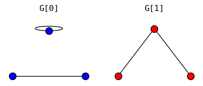

```
G[0]: <class 'networkx.classes.multigraph.MultiGraph'>
G[1]: <class 'networkx.classes.multigraph.MultiGraph'>
```

```python
G = []
plt.figure(figsize=(5, 1.5))
plt.subplots_adjust(wspace=.2)
for i, c in enumerate(['b', 'r']):
    G += [nx.configuration_model([1, 2, 1], seed=5056+i)]
    plt.subplot(121+i)
    plt.title('G[%d]\n'%i, family='monospace')
    nx.draw(G[-1], pos={0: (0, 0), 1: (1, 10), 2: (2, 0)},
            node_size=100, node_color=c, edgecolors='k')
plt.show(); print()

print('G[0]:', type(G[0])) # a MultiGraph because of a self-loop
print('G[1]:', type(G[1])) # also a MultiGraph although it looks simple
```

The [documentation](https://networkx.org/documentation/stable/reference/generated/networkx.generators.degree_seq.configuration_model.html) of `configuration_model` teaches users how to remove multi-edges and self-loops from its results. Although this action inevitably distorts the original degree sequence, we can show that it is not a big deal if $N$ is large. (On the other hand, the algorithm of the model is greatly simplified because of their existence. The algorithm will be much more tedious if you try to ban them when you pair up the stubs.)

```python
def print_info(G):
    print('\t{k}:', [k for n, k in G.degree()])
    print('\tedges:', G.edges)

G = nx.configuration_model([2, 2, 2, 2, 2, 2], seed=5056)
print('Original:')
print_info(G)

G = nx.Graph(G)
print('\nAfter removing multi-edges:')
print_info(G)

G.remove_edges_from(nx.selfloop_edges(G))
print('\nAfter removing self-loops:')
print_info(G)
```

```
Original:
	{k}: [2, 2, 2, 2, 2, 2]
	edges: [(0, 0, 0), (1, 1, 0), (2, 3, 0), (2, 3, 1), (4, 4, 0), (5, 5, 0)]

After removing multi-edges:
	{k}: [2, 2, 1, 1, 2, 2]
	edges: [(0, 0), (1, 1), (2, 3), (4, 4), (5, 5)]

After removing self-loops:
	{k}: [0, 0, 1, 1, 0, 0]
	edges: [(2, 3)]
```

In the following experiments I will use the degree sequence of the Florentine families (Breiger and Pattison, 1986). Each node represents a powerful family in Florence during Renaissance, and an edge between two nodes represents marriage between the two families.

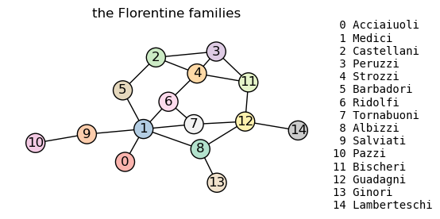

```python
LSC = mpl.colors.LinearSegmentedColormap
Pastel1, Pastel2 = mpl.cm.Pastel1, mpl.cm.Pastel2
cmap = LSC.from_list('', list(Pastel1.colors)+list(Pastel2.colors),
                     Pastel1.N+Pastel2.N) # 17 colours

florence = nx.convert_node_labels_to_integers(
    nx.florentine_families_graph(), label_attribute='family') # 15 nodes

plt.figure(figsize=(4, 2))
nx.draw_kamada_kawai(florence, edgecolors='k', cmap=cmap,
                     node_color=list(florence), with_labels=True)
plt.text(1.1, 0, '\n'.join(['%2d %s'%(i, f)
                            for i, f in florence.nodes('family')]),
         family='monospace', va='center')
plt.title('the Florentine families\n')

ks = np.array([k for n, k in florence.degree])
```

### Edge probability.

Consider a simple random network first. How likely are nodes $i$ and $j$ connected if they have degrees $k_i$ and $k_j$? We have solved this problem when we discussed modularity, and the answer is $p_{ij}=\dfrac{k_ik_j}{2E}$.

\begin{align} p_{ij} &= P\left(i\text{ joins }j\right) \\ &= k_i \times P\left(\text{a specific stub of }i\text{ joins }j\right) \\\ &= k_i \times k_j \times P\left(\text{a specific stub of }i\text{ joins a specific stub of }j\right) \\ &= k_i \times k_j \times \dfrac{1}{2E-1} \approx \dfrac{k_ik_j}{2E} \end{align}

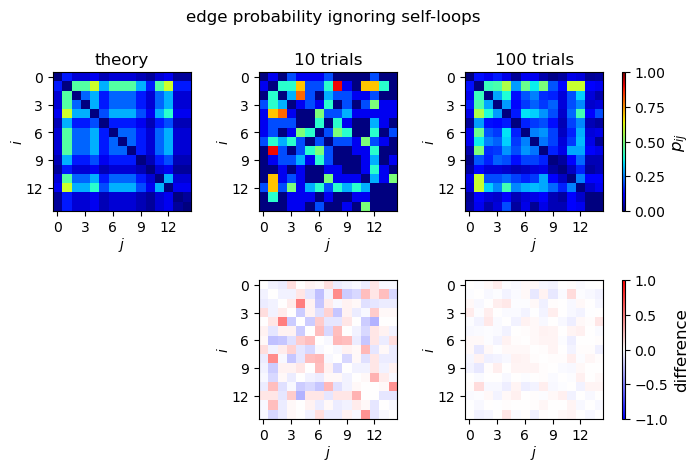

```python
N = florence.number_of_nodes()
E = florence.number_of_edges()

t1, t2 = 10, 100
pij_theory = ks.reshape(-1, 1) @ ks.reshape(1, -1) / (2*E)
pij_expt = lambda trials: sum(
    nx.to_numpy_array(nx.configuration_model(ks, seed=5056+t))
    for t in range(trials))/trials
pij_expt1, pij_expt2 = pij_expt(t1), pij_expt(t2)
for pij in [pij_theory, pij_expt1, pij_expt2]:
    np.fill_diagonal(pij, 0) # ignore self-loops first

fig,ax = plt.subplots(2, 3, figsize=(8, 4.5))
plt.subplots_adjust(hspace=.5, wspace=.3)
fig.suptitle('edge probability ignoring self-loops', y=1.02)
for r, row in enumerate(ax):
    for col, pij in zip(row, [pij_theory, pij_expt1, pij_expt2]):
        if r == 0: im = col.imshow(pij, cmap='jet', vmin=0, vmax=1)
        else: im = col.imshow(pij-pij_theory, cmap='bwr', vmin=-1, vmax=1)
        col.set_ylabel('$i$', labelpad=.25); col.set_yticks(range(0, N, 3))
        col.set_xlabel('$j$', labelpad=.25); col.set_xticks(range(0, N, 3))
    cb = fig.colorbar(im, ax=row, fraction=.05, pad=.03, aspect=50)
    cb.set_label('$p_{ij}$', fontsize=12)
cb.set_label('difference')

ax[0, 0].set_title('theory')
ax[0, 1].set_title('%d trials' % t1)
ax[0, 2].set_title('%d trials' % t2)
ax[1, 0].set_visible(False)
plt.show()
```

### Probability of multi-edges.

We can similarly calculate the probability $p^\left(2\right)_{ij}$ that $i$ and $j$ are connected with two edges.

\begin{align} p^\left(2\right) _ {ij} &= P\left(\text{two stubs of }i\text{ joins two stubs of }j\right) \\ &= \dfrac{k_ik_j}{2E} \times P\left[\text{one of }i\text{'s ($k_i-1$) free stubs joins one of }j\text{'s ($k_j-1$) free stubs}\right] \\ &= \dfrac{k_ik_j}{2E} \times \dfrac{\left(k_i-1\right)\left(k_j-1\right)}{2E} = \dfrac{k_ik_j\left(k_i-1\right)\left(k_j-1\right)}{\left(2E\right)^2} \end{align}

In general, the probability of having $n$ multi-edges between two nodes is proportional to $E^{-n}$, so it vanishes exponentially. We can therefore ignore cases in which two nodes are connected with more than two edges, meaning that we only expect there are $m=\dfrac{1}{2}\sum_i{\sum_j{p^\left(2\right)_{ij}}}$ multi-edges in total.

\begin{align} m &= \dfrac{1}{2}\sum_i\sum_j{\dfrac{k_ik_j\left(k_i-1\right)\left(k_j-1\right)}{\left(2E\right)^2}} \\ &= \dfrac{1}{2\langle{k}\rangle^2} \sum_i{\dfrac{k_i\left(k_i-1\right)}{N}} \sum_j{\dfrac{k_j\left(k_j-1\right)}{N}} & \left(2E=N\langle{k\rangle}\right) \\ &= \dfrac{1}{2} \left(\dfrac{\langle{k^2}\rangle-\langle{k}\rangle}{\langle{k}\rangle}\right)^2 \end{align}

Note that $m$ does not depend on $N$. When $N$ grows at fixed $\langle{k}\rangle$ and $\langle{k^2}\rangle$, the finite number of multi-edges will be shared by more nodes, so the probability for a node to have multi-edges is extremely small. In other words, when $N$ is large, the configuration model probably creates a simple network.

(By the way, the ratio $\dfrac{\langle{k^2}\rangle-\langle{k}\rangle}{\langle{k}\rangle}$ will appear again in the following derivations.)

```python
def m_expt(trials):
    m = 0
    for t in range(trials):
        G = nx.configuration_model(ks, seed=5056+t)
        m += sum(len(G[u][v]) for u, v in nx.Graph(G).edges if len(G[u][v])>1)
    return m/trials

ratio = ( (ks**2).mean()-ks.mean() )/ ks.mean()
m_theory = .5*ratio**2
m_theory, m_expt(10), m_expt(100)
```

```
(2.7612500000000013, 3.0, 2.48)
```

### Probability of self-loops.

The $k_i$ stubs of node $i$ can form $\left(\matrix{k_i \\ 2}\right)$ possible pairs among themselves. Since each specific pair of stubs joins with a probability $\dfrac{1}{2E-1}$, the probability for $i$ to have self-loops is

\begin{align} p_{ii} = \left(\matrix{k_i \\ 2}\right) \times \dfrac{1}{2E-1} \approx \dfrac{k_i\left(k_i-1\right)}{4E}\,. \end{align}

Again, the probability for a node to have $n$ self-loops scales with $E^{-n}$ and gets insignificant quickly, so the expected number of self-loops summing $p_{ii}$ is

\begin{align} s = \sum_i {p_{ii}} = \sum_i {\dfrac{k_i\left(k_i-1\right)}{4E}} = \dfrac{1}{2} \dfrac{\langle{k^2}\rangle-{\langle{k}\rangle}}{\langle{k}\rangle}\,. \end{align}

Because it is independent of $N$, the effect of self-loops on the configuration model also vanishes as $N$ grows.

```python
def s_expt(trials):
    s = 0
    for t in range(trials):
        G = nx.configuration_model(ks, seed=5056+t)
        s += len(list(nx.selfloop_edges(G)))
    return s/trials

s_theory = ratio/2
s_theory, s_expt(10), s_expt(100)
```

```
(1.1750000000000003, 1.0, 1.4)
```

### Clustering coefficient.

Since a node's edge connects itself to a specific $k$-degree node with probability $\dfrac{k}{2E-1}\approx\dfrac{k}{2E}$, the probability for the node to connect with a $k$-degree node is $\dfrac{k}{2E}\times{NP_k} = \dfrac{kP_k}{\langle{k}\rangle}\equiv p_k$.

Now consider three nodes $h$, $i$, and $j$ that are trying to form a triplet. First, $h$ links to both $i$ and $j$ with probability $p_{k_i}p_{k_j}$. Then, both $i$ and $j$ have already spent one stub for $h$, so the probability for them to connect reduces to $\dfrac{\left(k_i-1\right)\left(k_j-1\right)}{2E}$. Combining these statements, the configuration model's clustering coefficient reads

\begin{align} C &= \sum_{k_i=1}^\infty \sum_{k_j=1}^\infty {p_{k_i}p_{k_j}\dfrac{\left(k_i-1\right)\left(k_j-1\right)}{2E}} \\ &= \dfrac{1}{2E} \sum_{k_i=1}^\infty \sum_{k_j=1}^\infty {p_{k_i}p_{k_j}\left(k_i-1\right)\left(k_j-1\right)} \\ &= \dfrac{1}{2E} \left[ \sum_{k=1}^\infty {\left(k-1\right)p_k}\right ]^2 = \dfrac{1}{2E\langle{k}\rangle^2} \left[\sum_{k=1}^\infty {\left(k-1\right)kP_k}\right]^2 \\ &= \dfrac{1}{N\langle{k}\rangle^3} \Big(\langle{k^2}\rangle-\langle{k}\rangle\Big)^2 = \dfrac{1}{N\langle{k}\rangle} \left(\dfrac{\langle{k^2}\rangle-{\langle{k}\rangle}}{\langle{k}\rangle}\right)^2\,. \end{align}

Despite a different formulation from the ER network, the configuration model also yields $C\sim N^{-1}$ and violates empirical observations. This tells us again that real networks are not formed at random.

```python
def C_expt(trials):
    C = 0
    for t in range(trials):
        G = nx.configuration_model(ks, nx.Graph, 5056+t)
        C += nx.average_clustering(G)
    return C/trials

C_theory = ratio**2/(N*ks.mean())
C_theory, C_expt(10), C_expt(100)
```

```
(0.13806250000000006, 0.09533333333333335, 0.08995555555555548)
```

### Degree-preserving randomization.

If you desire to prevent $\left\{k\right\}$ from being distorted by any multi-edges or self-loops, degree-preserving randomization is an alternative way to realize the configuration model.

Given a network that follows $\left\{k\right\}$, the process iteratively chooses two arbitrary edges $\left(u,v\right)$ and $\left(x,y\right)$ and swaps their ends, resulting in $\left(u,x\right)$ and $\left(v,y\right)$. Obviously, a swap preserves the nodes' degrees. If the swap results in multi-edges or self-loops, the swap is discarded.

You may carry out the step with `double_edge_swap` or `connected_double_edge_swap`, which ensures the connectedness of the randomized network. Beware that the functions modify a network in-place, so save the original network if you need to reuse it.

More importantly, degree-preserving randomization nullifies all the equations derived above, but the deviation diminishes as $N$ grows.

```
Old degree sequence: [1, 6, 3, 3, 4, 2, 3, 3, 3, 2, 1, 3, 4, 1, 1]
New degree sequence: [1, 6, 3, 3, 4, 2, 3, 3, 3, 2, 1, 3, 4, 1, 1]
```

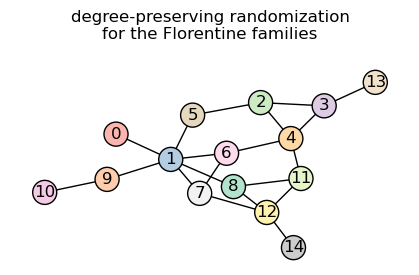

```python
print('Old degree sequence:', [k for n, k in florence.degree])
nx.double_edge_swap(florence, seed=5056)

plt.figure(figsize=(4, 2))
nx.draw_kamada_kawai(florence, edgecolors='k', cmap=cmap,
                     node_color=list(florence), with_labels=True)
plt.title('degree-preserving randomization\nfor the Florentine families\n')

print('New degree sequence:', [k for n,k in florence.degree])
```

# References

1. Albert R. and Barabási A.-L. (2002) *Statistical mechanics of complex networks*, Rev. Mod. Phys. **74**, 47.
2. Breiger R. L. and Pattison P. E. (1986) *Cumulated social roles: The duality of persons and their algebras*, Soc. Netw. **8**, 215.
3. Erdős P. and Rényi A. (1958) *On random graphs I*, Publ. Math. Debrecen **6**, 290.
4. Gilbert E. N. (1959) *Random Graphs*, Ann. Math. Stat. **30**, 1141.